# 03_Annotation

Nick Diercksen

Last compiled on 2023-06-16 18:38:08

# About

This step is a preparation for the following Gene Set Enrichment Analysis (GSEA with `fgsea`) and GO analysis.

To link the genes with the pathways the Entrez IDs (“entrezgene_id”) is needed. Therefore the `biomaRt` interface is used to access the corresponding DBs.

# read in data

The Ensembl gene IDs can be found in the saved SummarizedExperiment object. As the genes are the same for gastrocnemius and soleus, only one set needs to be loaded. The Ensembl IDs can be used to query the ensembl.org database.

```r
se.gastroc <- readRDS("./data/Robjects/01_se.gastroc.rds")
ensembl_ids <- rownames(se.gastroc)
```

# query biomaRt for annotations

For the mouse dataset (“mmusculus_gene_ensembl”) the ensembl.org database is queried for entries of the current Ensembl IDs. Besides the “entrezgene_id” some further annotation data is requested to compare already available annotation data.

```r
#
ensembl.mart <- useMart(biomart = "ensembl", dataset = "mmusculus_gene_ensembl", host = 'https://www.ensembl.org')

filterType <- "ensembl_gene_id"
attributeNames <- c('ensembl_gene_id',
                    'entrezgene_id',
                    'external_gene_name',
                    'description',
                    'gene_biotype',
                    'chromosome_name',
                    'start_position',
                    'end_position',
                    'strand')
# run the query
annot <- getBM(attributes=attributeNames,
               filters = filterType,
               values = ensembl_ids,
               mart = ensembl.mart) %>%
  dplyr::rename(GeneID=ensembl_gene_id)
```

[output not shown]

# exploring the annotation dataset:

duplicate ids:

```r
sum(duplicated(annot$GeneID))
```

```
[1] 301
```

## missing genes

```r
missingGenes <- ! ensembl_ids %in% annot$GeneID
print(paste0("There are ", sum(missingGenes), " genes not having an entry in the GRCm39 assembly genome"))
```

```
[1] "There are 3547 genes not having an entry in the GRCm39 assembly genome"
```

```r
ensembl_ids[missingGenes] %>% head(20)
```

```
 [1] "ENSMUSG00000000325" "ENSMUSG00000011052" "ENSMUSG00000021745"
 [4] "ENSMUSG00000021867" "ENSMUSG00000022915" "ENSMUSG00000023577"
 [7] "ENSMUSG00000024952" "ENSMUSG00000029386" "ENSMUSG00000030771"
[10] "ENSMUSG00000035310" "ENSMUSG00000035364" "ENSMUSG00000039530"
[13] "ENSMUSG00000043498" "ENSMUSG00000044021" "ENSMUSG00000046088"
[16] "ENSMUSG00000048191" "ENSMUSG00000048544" "ENSMUSG00000051219"
[19] "ENSMUSG00000051412" "ENSMUSG00000052471"
```

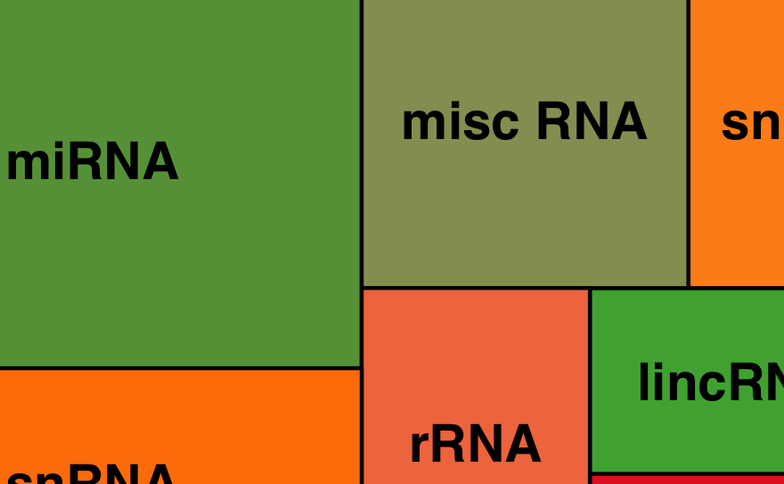

```r
biotype_colors <- table(rowData(se.gastroc)$gene_biotype, dnn = c("biotype")) %>%
  as.data.frame() %>%
  mutate(
    biotype = stringr::str_replace_all(biotype, "_", " "),
    colors = params$treemap_pal(n())
    ) %>%
  dplyr::select(-Freq)


genes_without_entrez <- rowData(se.gastroc) %>% as.data.frame() %>% .[missingGenes,]

gene_biotypes <- table(genes_without_entrez$gene_biotype, dnn = c("biotype")) %>%
  as.data.frame() %>%
  mutate(
    biotype = stringr::str_replace_all(biotype, "_", " "),
    ) %>%
  arrange(desc(Freq)) %>%
  merge(biotype_colors, by = "biotype") # obtain the same colors

treemap::treemap(gene_biotypes,
                 type = "color",
                 index = "biotype",
                 vSize = "Freq",
                 vColor = "colors",
                 title = "Gene biotypes",
                 fontsize.labels = 20)
```

on the example of gastrocnemius looking at how many of those genes were already filtered out and not important:

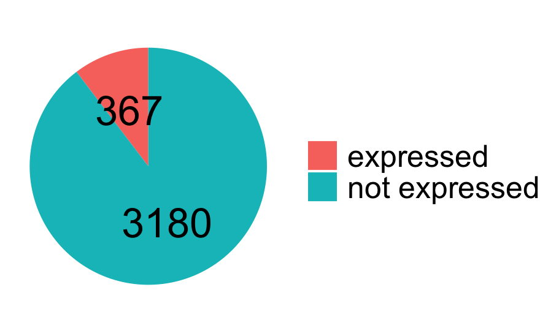

```r
filtered.df <- data.frame(
  group = c("expressed", "not expressed"),
  value = c(sum(genes_without_entrez$filtered), sum(!genes_without_entrez$filtered))
)
ggplot(filtered.df, aes(x="", y=value, fill=group)) +
  geom_bar(stat="identity", width=1) +
  geom_text(aes(label = value),
            position = position_stack(vjust = 0.5), size = 8) +
  coord_polar("y", start=0) +
  theme_void() +
  theme(legend.text = element_text(size = 17), legend.title = element_blank())
```

## consistency in the metadata (sanity checks)

the metadata from the genes originates from two sources:

- already provided with the available counts
- from biomart (Ensembl)

The question is if both datasets are consistent with the data they provide. Inconsistencies can point to possible mistakes done when annotating.

So before merging the new annotation data into the `se` to get the “entrezgene_id” to later do the pathway enrichment.

```r
df <- merge(annot, rowData(se.gastroc), by.x = 1, by.y = 0) %>%
  as.data.frame()
```

### biotypes:

```r
cols <- c("GeneID","gene_biotype.x", "gene_biotype.y")
dif_biotypes <- !df$gene_biotype.x == df$gene_biotype.y
print(paste0("There are ", sum(dif_biotypes), " genes annotated with different biotypes"))
```

```
[1] "There are 9630 genes annotated with different biotypes"
```

```r
df[(dif_biotypes),cols] %>% head(20)
```

|  | GeneID | gene_biotype.x | gene_biotype.y |
| --- | --- | --- | --- |
| 4 | ENSMUSG00000000031 | lncRNA | lincRNA |
| 1003 | ENSMUSG00000006395 | protein_coding | polymorphic_pseudogene |
| 1015 | ENSMUSG00000006462 | lncRNA | lincRNA |
| 1045 | ENSMUSG00000006638 | protein_coding | processed_transcript |
| 1254 | ENSMUSG00000009551 | lncRNA | protein_coding |
| 1329 | ENSMUSG00000010492 | lncRNA | antisense |
| 1374 | ENSMUSG00000011350 | lncRNA | processed_transcript |
| 1442 | ENSMUSG00000013562 | lncRNA | lincRNA |
| 1612 | ENSMUSG00000015451 | lncRNA | processed_transcript |
| 1946 | ENSMUSG00000018451 | protein_coding | lincRNA |

[output cut: 10 more lines]

About a fifth of the genes is annotated with a different biotype. This has to be looked at more specifically though, since this could still be viable in the biological sense.

### gene names

```r
cols <- c("GeneID", "external_gene_name", "gene_name")
dif_names <- !df$external_gene_name == df$gene_name
print(paste0("There are ", sum(dif_names), " genes annotated with different gene names"))
```

```
[1] "There are 4001 genes annotated with different gene names"
```

```r
df[(dif_names), cols] %>% head(20)
```

|  | GeneID | external_gene_name | gene_name |
| --- | --- | --- | --- |
| 86 | ENSMUSG00000000486 | Septin1 | Sept1 |
| 87 | ENSMUSG00000000486 | Septin1 | Sept1 |
| 90 | ENSMUSG00000000531 | Tamalin | Grasp |
| 100 | ENSMUSG00000000563 | Atp5pb | Atp5f1 |
| 309 | ENSMUSG00000001755 | Coasy | Ppat |
| 328 | ENSMUSG00000001833 | Septin7 | Sept7 |
| 407 | ENSMUSG00000002280 | Ciao3 | Narfl |
| 549 | ENSMUSG00000003208 | Yju2 | Ccdc94 |
| 605 | ENSMUSG00000003527 | Ess2 | Dgcr14 |
| 754 | ENSMUSG00000004709 | Cd244a | Cd244 |

[output cut: 10 more lines]

Not as many differences as the biotypes, and most of them seem to be synonyms:

- http://www.ensembl.org/Mus_musculus/Gene/Summary?db=core;g=ENSMUSG00000002280;r=17:25992750-26002306
- http://www.ensembl.org/Mus_musculus/Gene/Summary?db=core;g=ENSMUSG00000003527;r=16:17718573-17729212

### chromosome

```r
cols <- c("GeneID", "chromosome_name", "gene_chr", "external_gene_name", "gene_name")
df[(!df$chromosome_name == df$gene_chr), cols] %>% head(20)
```

|  | GeneID | chromosome_name | gene_chr | external_gene_name | gene_name |
| --- | --- | --- | --- | --- | --- |
| 18438 | ENSMUSG00000065387 | 17 | 9 | Gm55596 | n-R5s85 |
| 21260 | ENSMUSG00000076377 | 16 | 10 | Gm54624 | Gm22370 |

Here we “only” have 2 genes annotated with different chromosomes, but this might be one of the more severe differences!

**ENSMUSG00000065387**

- “5S_rRNA”: is known in mammals (Pan troglodytes[Chimpanzee], Canis familiaris[Dog], Bos Taurus[Cow])
- “n-R5s85”: is a gene in “Mus musculus” (What is expected)

[Source](https://www.genecards.org/cgi-bin/carddisp.pl?gene=RNA5SP273)

=> Could this mean, that external_gene_name is wrongly matched to other species than mouse?

**ENSMUSG00000076377**

- “Gm22370”: is assigned to Mouse as “ENSMUST00000102422.1” (ensembl transcript id) [Source](http://rnact.crg.eu/rnas?page=228)

### gene positions

#### start

```r
dif_start <- df$start_position - df$gene_start
head(dif_start, 20)
```

```
 [1]   -92684  -956394  -181250  -446267 -1251672  -109174  -109174       -1
 [9]    49999  -142803   -92717  -109174  -109174        0  -109174  -109174
[17]  -109174   274039  -400828  -133761
```

```r
summary(dif_start)
```

```
     Min.   1st Qu.    Median      Mean   3rd Qu.      Max.
-94325000   -164136    -72271    -40838     50000  27676887
```

total genes with the same start position

```r
sum(dif_start == 0)
```

```
[1] 1463
```

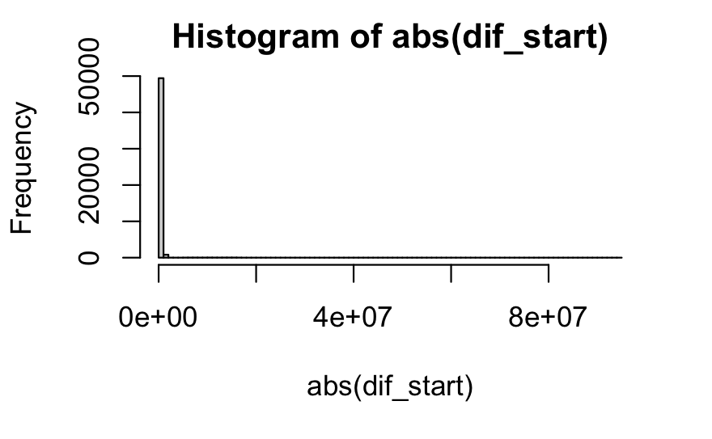

```r
hist(abs(dif_start), breaks = 100)
```

These differ quite substantially. Either these are different metrics or really relating to a different species.

#### end

```r
dif_end <- df$end_position - df$gene_end
head(dif_end, 20)
```

```
 [1]   -92684  -956394  -181250  -446257 -1217004  -109174  -109174       -1
 [9]    49999  -142803   -92717  -109174  -109174        0  -109174  -109174
[17]  -109174   306997  -400828  -133761
```

```r
summary(dif_end)
```

```
     Min.   1st Qu.    Median      Mean   3rd Qu.      Max.
-94325016   -164136    -72270    -40643     50000  27676908
```

total genes with the same end position

```r
sum(dif_end == 0)
```

```
[1] 1461
```

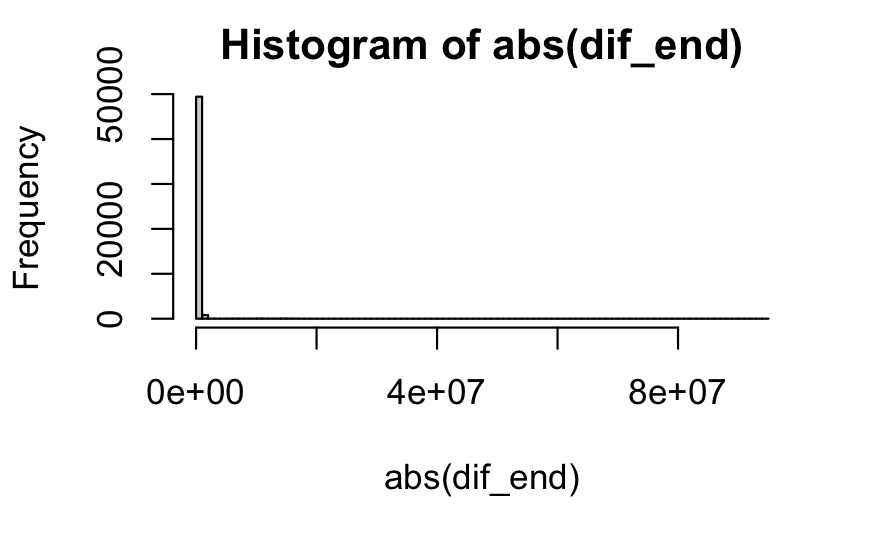

```r
hist(abs(dif_end), breaks = 100)
```

Similar to the start.

## Discussion

On the first glance, there are several inconsistencies with the two annotation sources. Whether and where a wrong data source was chosen has to be examined.

Gene length was not compared, since no field was available and subtracting the start from the end position would not make sense (introns would probably get counted as well).

# reviewing joined annotations

As some genes share the same Entrez IDs, several of those are displayed in the following.

## duplicated Entrez IDs

```r
# getting all genes which have entrez gene id assigned
rdata.entrez <- as.data.frame(rowData(se.gastroc)) %>%
    tibble::rownames_to_column("GeneID") %>%
    left_join(annot, by=c("GeneID")) %>%
    filter(!is.na(entrezgene_id))
print(paste0(nrow(rdata.entrez), "/", nrow(se.gastroc), " genes were annotated with entrez gene ids"))
```

```
[1] "26508/53801 genes were annotated with entrez gene ids"
```

```r
# getting duplicate
dups.entrez <- rdata.entrez$entrezgene_id %>%
  base::duplicated() %>%
  which() %>%
  rdata.entrez$entrezgene_id[.]

subset(rdata.entrez, entrezgene_id %in% dups.entrez) %>%
  dplyr::select(GeneID, entrezgene_id, external_gene_name) %>%
  arrange(entrezgene_id, ) %>%
  head()
```

|  | GeneID | entrezgene_id | external_gene_name |
| --- | --- | --- | --- |
| 1 | ENSMUSG00000022194 | 12050 | Pabpn1 |
| 2 | ENSMUSG00000089682 | 12050 | Bcl2l2 |
| 3 | ENSMUSG00000025867 | 12890 | Cplx2 |
| 4 | ENSMUSG00000112941 | 12890 | Gm48623 |
| 5 | ENSMUSG00000089847 | 14356 | Timm10b |
| 6 | ENSMUSG00000110234 | 14356 | Gm45799 |

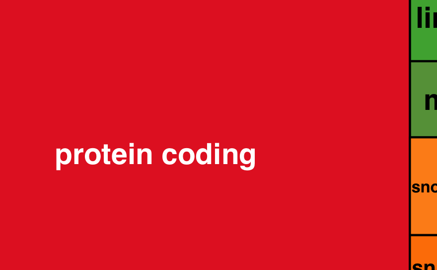

```r
gene_biotypes <- table(rdata.entrez$gene_biotype.x, dnn = c("biotype")) %>%
  as.data.frame() %>%
  mutate(
    biotype = stringr::str_replace_all(biotype, "_", " "),
    ) %>%
  arrange(desc(Freq)) %>%
  merge(biotype_colors, by = "biotype") # obtain the same colors

treemap::treemap(gene_biotypes,
                 type = "color",
                 index = "biotype",
                 vSize = "Freq",
                 vColor = "colors",
                 title = "Gene biotypes",
                 fontsize.labels = 20)
```

on the example of gastrocnemius looking at how many of those genes were already filtered out and not important:

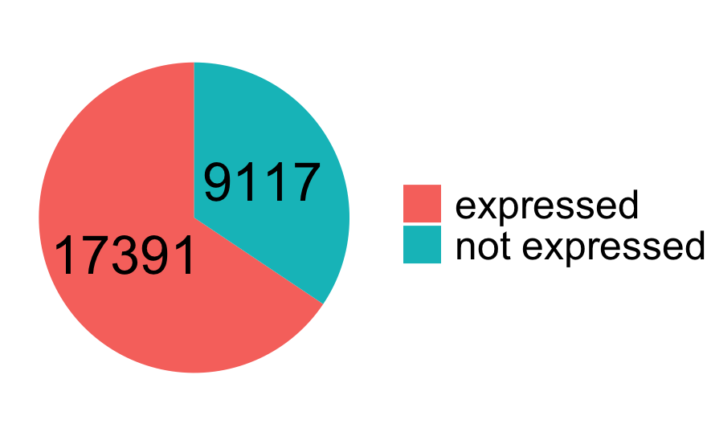

```r
filtered.df <- data.frame(
  group = c("expressed", "not expressed"),
  value = c(sum(rdata.entrez$filtered), sum(!rdata.entrez$filtered))
)
ggplot(filtered.df, aes(x="", y=value, fill=group)) +
  geom_bar(stat="identity", width=1) +
  geom_text(aes(label = value),
            position = position_stack(vjust = 0.5), size = 8) +
  coord_polar("y", start=0) +
  theme_void() +
  theme(legend.text = element_text(size = 17), legend.title = element_blank())
```

## duplicate ENSMUS

ENSMUS identifier are mostly transcripts of genes. Thus there are some genes mapping to multiple ENSMUS ids. ! this might have been induced by the joining of the downloaded annotations, which already had duplicate entrez IDS.

```r
# genes in GRCm39 that have
dups.GeneID <- annot$GeneID %>%
  base::duplicated() %>%
  annot$GeneID[.] %>%
  unique()

subset(annot, GeneID %in% dups.GeneID) %>%
  dplyr::select(GeneID, entrezgene_id, external_gene_name) %>%
  arrange(GeneID, )
```

[output not shown]

```r
dups <- annot %>%
  dplyr::select("GeneID", "external_gene_name") %>%
  duplicated()

# this implies some genes can be annotated with several pathways and rowData can't just be extended
# does something

annot_withDups <- annot
annot <- annot_withDups[!dups,]
```

# save Data

```r
# TODO: merge `annot` into se metadata, rowData is not compatible?
save(annot, file = "./data/Robjects/03_annot.RData")
```

this is currently used again in `04_fgsea`.